# Video sharing analysis

Webster

28 November 2021

# 1 Exercise overview

The company (simulated data) allows users to upload videos online, just like YouTube. This company is interested in knowing whether a video is “hot” (i.e. trending up in terms of popularity), stable or going down. Understanding this would allow to optimize the videos promoted on the home-page and, therefore, maximize ads revenue.

Currently, there is a major problem for the site - a very high home page drop-off rate. That is, users come to the home-page and then leave the site without taking any action or watching any video. Since customer acquisition costs are very high, this is a huge problem: the company is spending a lot of money to acquire users who don’t generate any revenue by clicking on ads.

Currently, the videos shown on the home page to new users are manually chosen. The Head of Product had this idea of creating a new recommended video section on the home page.

We need to do the following tasks:

1. Classify each video into one these 3 categories:
   1. ”Hot” - means trending up. These videos are candidate to be shown.
   2. “Stable and Popular” - video view counts are flat, but very high. These videos are candidates to be shown too.
   3. “Everything else” - these videos won’t be shown.
2. What are the main characteristics of the “hot videos”?
3. After having identified the characteristics of the hot videos, how would you use this information from a product standpoint?

# 2 Load and explore data

## 2.1 First, load the data

```r
#Set seed for reproducibility
set.seed(1003)
#Set directory
i_am("01. Video sharing analysis.Rmd")

#Load data
vid_count <- read_csv(here("raw","video_count.csv"))
vid_features <- read_csv(here("raw","video_features.csv"))

#Have a look at the data
vid_count %>% glimpse()
```

```
## Rows: 41,775
## Columns: 3
## $ video_id <dbl> 2303, 1193, 1219, 1472, 2947, 1417, 1564, 2962, 2057, 1785, 1…
## $ count    <dbl> 22, 54854, 1788779, 234, 14407, 973996, 42, 278000, 1134427, …
## $ date     <date> 2015-01-07, 2015-01-12, 2015-01-03, 2015-01-04, 2015-01-08, …
```

```r
vid_features %>% glimpse()
```

```
## Rows: 2,785
## Columns: 5
## $ video_id          <dbl> 2374, 1897, 2386, 2912, 2432, 2385, 2104, 1142, 460,…
## $ video_length      <dbl> 1760, 489, 1273, 986, 1050, 377, 380, 988, 1226, 114…
## $ video_language    <chr> "Cn", "Cn", "Es", "Es", "Other", "Cn", "En", "Other"…
## $ video_upload_date <date> 2014-12-06, 2014-12-10, 2014-12-05, 2014-12-10, 201…
## $ video_quality     <chr> "480p", "720p", "480p", "240p", "480p", "360p", "720…
```

## 2.2 Basic cleaning

Here we do some basic cleaning. We merge the two datasets into one by `video_id`.

```r
df <- vid_count %>%
  left_join(vid_features)
```

# 3 Classifying videos into groups

Based on the data, we are asked to group the videos into 3 groups. An approach could be the following:

1. Plot, for each `video_id`, the corresponding time series of views & get a best fit linear estimate
2. For those videos with slopes less than 0 and significant, we categorise them as “everything else”
3. Of the remaining videos, we select those videos with slopes more than 0 and significant, and label them as “Hot”
4. Lastly, we set a threshold X - any videos with a moving average view count above X would be labelled as “Stable and Popular”

```r
model <- df %>%
  #Group by videos
  group_by(video_id) %>%
  # #Arrange dates and generate customer "counter" for the time series
  # arrange(date) %>%
  # mutate(day_number = row_number()) %>%
  nest() %>%
  #Obtain corresponding time series.
  mutate(ols = map(.x = data,
                   ~lm(count ~ date, data = .x)))


# Getting coefficients
model <- model %>%
  mutate(coefficients = map(.x = ols, ~tidy(.x))) %>%
  unnest(coefficients)

model %>% head
```

```
## # A tibble: 6 × 8
## # Groups:   video_id [3]
##   video_id data              ols    term   estimate std.error statistic  p.value
##      <dbl> <list>            <list> <chr>     <dbl>     <dbl>     <dbl>    <dbl>
## 1     2303 <tibble [15 × 6]> <lm>   (Inte…  8.44e+2   8.13e+2      1.04  3.18e-1
## 2     2303 <tibble [15 × 6]> <lm>   date   -5.00e-2   4.94e-2     -1.01  3.30e-1
## 3     1193 <tibble [15 × 6]> <lm>   (Inte…  3.24e+8   2.19e+7     14.8   1.63e-9
## 4     1193 <tibble [15 × 6]> <lm>   date   -1.97e+4   1.33e+3    -14.8   1.64e-9
## 5     1219 <tibble [15 × 6]> <lm>   (Inte… -9.32e+8   1.20e+8     -7.78  3.02e-6
## 6     1219 <tibble [15 × 6]> <lm>   date    5.68e+4   7.28e+3      7.80  2.95e-6
```

Let’s have a look at one of the videos (randomly selected). From the `date` coefficient estimate, we can see that the estimate is negative and significant. In this instance, we would categorise the video in the “everything else” category. For completeness, we also plot a bar chart to visually inspect the viewing trends - here we see that the conclusion from the time series model still holds: *the video used to be incredibly popular, but is quickly losing popularity*.

```r
model %>%
    filter(video_id == 1) %>%
    select(term:p.value)
```

```
## # A tibble: 2 × 6
## # Groups:   video_id [1]
##   video_id term          estimate std.error statistic  p.value
##      <dbl> <chr>            <dbl>     <dbl>     <dbl>    <dbl>
## 1        1 (Intercept) 142118541.  6771665.      21.0 2.07e-11
## 2        1 date            -8639.      412.     -21.0 2.08e-11
```

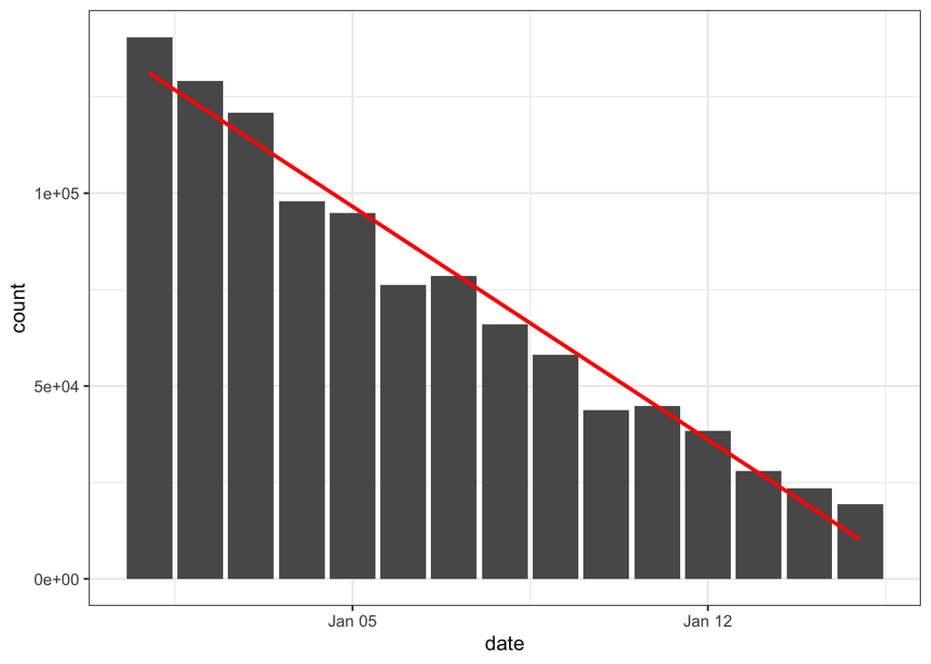

```r
  df %>%
    filter(video_id == 1) %>%
    ggplot(aes( x= date, y =count)) +
    geom_bar(stat = "identity") +
    geom_smooth(method = "lm", se = FALSE, color = "red") +
    theme_bw()
```

Let’s now classify all the videos into one of the three groups.

```r
everything_else <- model %>%
  #extract date coefficients only
  filter(term == "date",
        #apply everything else filters
         estimate < 0 & p.value < 0.05) %>%
  #extract video id
  pull(video_id)

hot <- model %>%
  #take out "everything else" videos
  filter(!(video_id %in% everything_else),
         term == "date",
         #Filter out positive slopes and significant as "hot"
         estimate > 0 & p.value < 0.05
         ) %>%
  #extract video id
  pull(video_id)
```

Now we are left with some videos that require further classification - some are “stable and popular” while others would fall into “everything else”. We have a look at how the moving average of video views looks like over time. It appears that there are two peaks - one close to 0 and another close to 2 million. Obviously, those close to 0 are not going to be categorised as “stable and popular”. In this instance, we take the second peak as the threshold for “stable and popular”.

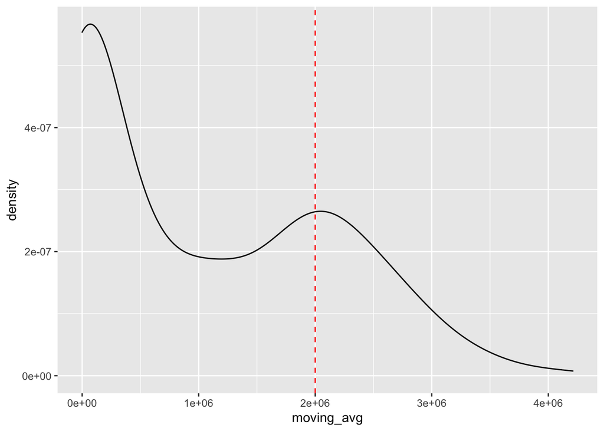

```r
remaining_vids <- model %>%
  #take out "everything else" videos
  filter(!(video_id %in% everything_else),
         !(video_id %in% hot)
  ) %>%
  #extract video id
  pull(video_id) %>%
  unique()

#calculate moving average views for these videos
moving_averages <- df %>%
  filter(video_id %in% remaining_vids) %>%
  group_by(video_id) %>%
  summarize(moving_avg = mean(count))

#Looking at density plots
moving_averages %>%
  ggplot(aes(x = moving_avg)) +
  geom_density()  +
  geom_vline(xintercept = 2000000, color = "red", linetype = 2)
```

```r
# Final categorisation of videos
everything_else_2 <- moving_averages %>%
  filter(video_id %in%
           (moving_averages %>%
              filter(moving_avg <2000000) %>%
              pull(video_id))) %>%
  pull(video_id)

stable_and_popular <- moving_averages %>%
  filter(video_id %in%
           (moving_averages %>%
              filter(moving_avg >=2000000) %>%
              pull(video_id))) %>%
  pull(video_id)

everything_else <- c(everything_else,everything_else_2)





#Define vectors to merge
everything_else <- tibble(video_id = everything_else,
                          type ="everything else")

stable_and_popular <- tibble(video_id = stable_and_popular,
                          type ="stable and popular")

hot <- tibble(video_id = hot,
                          type ="hot")


df <- df %>%
  left_join(everything_else) %>%
  left_join(stable_and_popular, by = "video_id") %>%
  left_join(hot, by = "video_id") %>%
  mutate(type_final = coalesce(type,type.x,type.y)) %>%
  select(-(type.x:type))
```

# 4 What are the main characteristics of the “hot videos”?

Since we already have the labels, we can simply build a machine learning classifier trying to separate hot videos from the other ones. We can use a decision tree here since we care mainly about the descriptive statistics part and less about the actual prediction. We add a few other variables such as week of the year and day of the week.

```r
tree_data <- df %>% arrange(video_id) %>%
  select(video_id,
         video_length,
         video_language,
         video_upload_date,
         video_quality,
         type_final) %>%
  #extract distinct values
  distinct() %>%
  #Add new date variables
  mutate(week = week(video_upload_date),
         day = weekdays(video_upload_date)) %>%
select(-video_id, -video_upload_date)

tree_data[sapply(tree_data,is.character)] = lapply(tree_data[sapply(tree_data,is.character)],as.factor)

tree = rpart(type_final ~ ., tree_data,
             #set max tree dept at 4. Bigger than that it just becomes too messy
             control = rpart.control(maxdepth = 4,
              #cp: if using trees for insights, set this parameter low. R default value is a bit aggressive and might result in fewer splits, which is good for prediction (avoids overfitting), but not so good for insights
             cp = 0.00001),
             #change weights. Dataset is now perfectly balanced. It makes easier to look at the output
             # parms = list(prior = c(0.5, 0.5)),
             model=TRUE
             )

tree
```

```
## n= 2785
##
## node), split, n, loss, yval, (yprob)
##       * denotes terminal node
##
##  1) root 2785 966 everything else (0.65314183 0.30843806 0.03842011)
##    2) week< 50.5 2106 452 everything else (0.78537512 0.17426401 0.04036087)
##      4) week< 49.5 921  52 everything else (0.94353963 0.04343105 0.01302932) *
##      5) week>=49.5 1185 400 everything else (0.66244726 0.27594937 0.06160338)
##       10) day=Friday,Saturday,Sunday,Thursday,Wednesday 853 233 everything else (0.72684642 0.21219226 0.06096131) *
##       11) day=Monday,Tuesday 332 167 everything else (0.49698795 0.43975904 0.06325301)
##         22) video_length>=29 322 157 everything else (0.51242236 0.42236025 0.06521739) *
##         23) video_length< 29 10   0 hot (0.00000000 1.00000000 0.00000000) *
##    3) week>=50.5 679 187 hot (0.24300442 0.72459499 0.03240059)
##      6) day=Thursday,Wednesday 409 187 hot (0.40342298 0.54278729 0.05378973)
##       12) week< 51.5 355 187 hot (0.46478873 0.47323944 0.06197183)
##         24) video_quality=1080p 121  50 everything else (0.58677686 0.38016529 0.03305785) *
##         25) video_quality=240p,360p,480p,720p 234 112 hot (0.40170940 0.52136752 0.07692308) *
##       13) week>=51.5 54   0 hot (0.00000000 1.00000000 0.00000000) *
##      7) day=Friday,Monday,Saturday,Sunday,Tuesday 270   0 hot (0.00000000 1.00000000 0.00000000) *
```

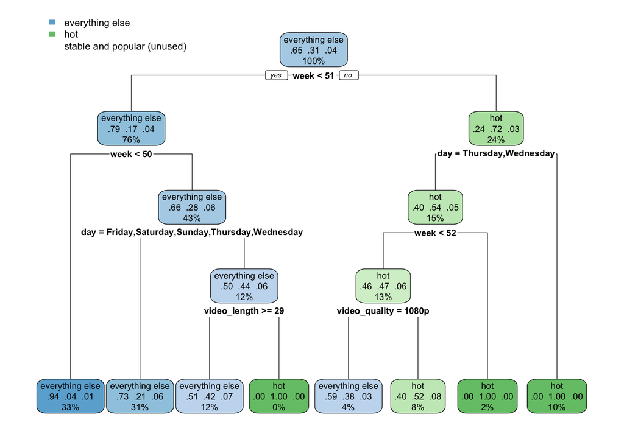

```r
rpart.plot(tree)
```

Main findings from the tree is that “Hot” videos are usually those that are uploaded later in the year (i.e. more recent). This also makes sense because the “hot” videos are defined as having a significant positive slope - so by construction a video uploaded at an earlier date is less likely to be defined “hot”. If we were to remove the time variables, we can have a better picture of the characteristics of the videos that are “hot”.

It is clear that shorter videos (<14 minutes) perform better. Additionally, it appears that language is not relevant in the determination of “hot” videos.

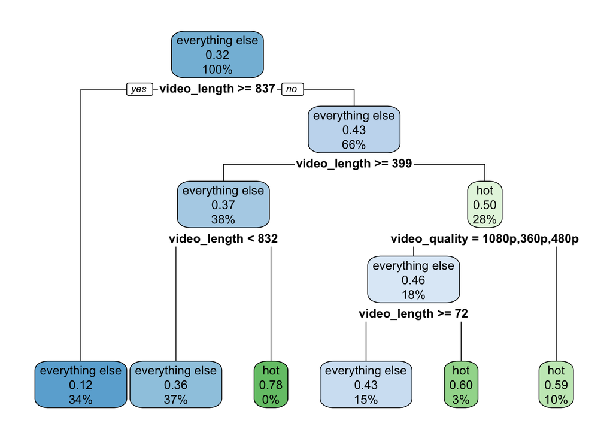

```r
tree_no_time <-  rpart(type_final ~ ., tree_data %>%
                         select(-week,-day) %>%
                         filter(type_final != "stable and popular"),
                       #set max tree dept at 4. Bigger than that it just becomes too messy
                       control = rpart.control(maxdepth = 4,
                                               #cp: if using trees for insights, set this parameter low. R default value is a bit aggressive and might result in fewer splits, which is good for prediction (avoids overfitting), but not so good for insights
                                               cp = 0.00001),
                       #change weights. Dataset is now perfectly balanced. It makes easier to look at the output
                       # parms = list(prior = c(0.5, 0.5)),
                       model=TRUE
)

rpart.plot(tree_no_time)
```

# 5 How can we use this information from a product standpoint?

We can work towards encouraging users to upload shorter videos.

In particular, we can set up a test:

- In the treatment group, we nudge users by having a pop-up informing them that they could “potentially get Y% more views and hence Z% more ad-revenue”
- In the control group, we leave things as is.

We would then look at how the videos from the two groups perform on average and verify our hypothesis.